# PML Project: Human Activity Recognition

Lakshmi Kuchipudi

Thursday, December 24, 2015

**Feature Selection:** The original data set had 160 variables of which 101 are descriptive statistics computed over a group of data. These statistics were not used in model building. We also excluded names and index variables. All the 59 variables were used as predictor for training our model.

**Data Partition:** The data set was partitioned into training(70%) and test data sets(30%).

**Machine Learning Models selected:** The response variable is a categorical variables with 5 levels - A, B, C, D, E. This is a classification problem so the models considered are Decision trees and Random Forests.

*Decision trees* with 10 fold cross validation and 3 repeats was used to train the model on the partitioned training data set. The out of sample accuracy was approximately 96%.

```
## Confusion Matrix and Statistics
##
##           Reference
## Prediction    A    B    C    D    E
##          A 1384    4    1    6    0
##          B   17  909   19    4    0
##          C    3   12  812   25    3
##          D    8    0   24  761   11
##          E    7    0    5   29  860
##
## Overall Statistics
##
##                Accuracy : 0.9637
##                  95% CI : (0.9581, 0.9688)
##     No Information Rate : 0.2894
##     P-Value [Acc > NIR] : < 2.2e-16
##
##                   Kappa : 0.9541
##  Mcnemar's Test P-Value : NA
##
## Statistics by Class:
##
##                      Class: A Class: B Class: C Class: D Class: E
## Sensitivity            0.9753   0.9827   0.9431   0.9224   0.9840
## Specificity            0.9968   0.9899   0.9894   0.9895   0.9898
## Pos Pred Value         0.9921   0.9579   0.9497   0.9465   0.9545
## Neg Pred Value         0.9900   0.9960   0.9879   0.9844   0.9965
## Prevalence             0.2894   0.1886   0.1756   0.1682   0.1782
## Detection Rate         0.2822   0.1854   0.1656   0.1552   0.1754
## Detection Prevalence   0.2845   0.1935   0.1743   0.1639   0.1837
## Balanced Accuracy      0.9861   0.9863   0.9662   0.9559   0.9869
```

*Random forests* approach has been modelled using both “random forest” function in random forest package as well as the “rf” in the caret package. Both approaches showed similar results. The variable cvtd_timestamp was also excluded since its a factor with 17 levels. Adding this variable slowed down the training process. When excluded, significantly improved the performance. The “random forest” function from random forest package took about 10sec versus “rf” in the caret package which took about 10min. The out of sample accuracy for this model was close to 100%.

```
## Confusion Matrix and Statistics
##
##           Reference
## Prediction    A    B    C    D    E
##          A 1395    0    0    0    0
##          B    0  949    0    0    0
##          C    0    2  852    1    0
##          D    0    0    1  800    3
##          E    0    0    0    1  900
##
## Overall Statistics
##
##                Accuracy : 0.9984
##                  95% CI : (0.9968, 0.9993)
##     No Information Rate : 0.2845
##     P-Value [Acc > NIR] : < 2.2e-16
##
##                   Kappa : 0.9979
##  Mcnemar's Test P-Value : NA
##
## Statistics by Class:
##
##                      Class: A Class: B Class: C Class: D Class: E
## Sensitivity            1.0000   0.9979   0.9988   0.9975   0.9967
## Specificity            1.0000   1.0000   0.9993   0.9990   0.9998
## Pos Pred Value         1.0000   1.0000   0.9965   0.9950   0.9989
## Neg Pred Value         1.0000   0.9995   0.9998   0.9995   0.9993
## Prevalence             0.2845   0.1939   0.1739   0.1635   0.1841
## Detection Rate         0.2845   0.1935   0.1737   0.1631   0.1835
## Detection Prevalence   0.2845   0.1935   0.1743   0.1639   0.1837
## Balanced Accuracy      1.0000   0.9989   0.9990   0.9983   0.9982
```

**Model Selection:** The model built using random forest resulted in the highest accuracy approximately 100% and was selected to predict the manner in which they did the exercises with the response variable classe.

The top 5 most *important variables* in random forests approach are new_window, raw_timestamp_part_2, gyros_arm_z, gyros_forearm_x, gyros_dumbbell_z.

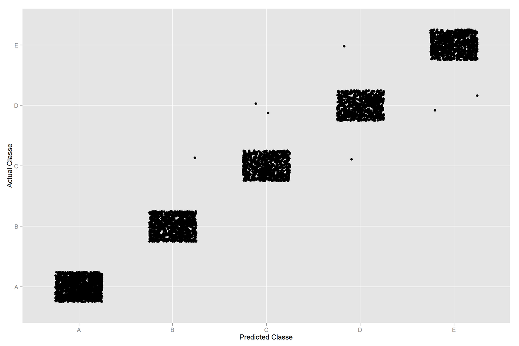

**Validation dataset:** The reponse variable “classe” values for the validation dataset were predicted using both the models built using Decision Trees as well as Random Forest models. Both the model resulted in same values.